# Terrorist Attack Analysis in Afghanistan 2002 - 2017

# Time Series Forecasting

In examining the terrorist attacks, it would be beneficial to note any patterns or seasonal effects. Due to the large spike in 2012, only the years 2013-2017 were examined. When examining seasonal data, it is common to separately examine pieces that appear to be naturally separated.

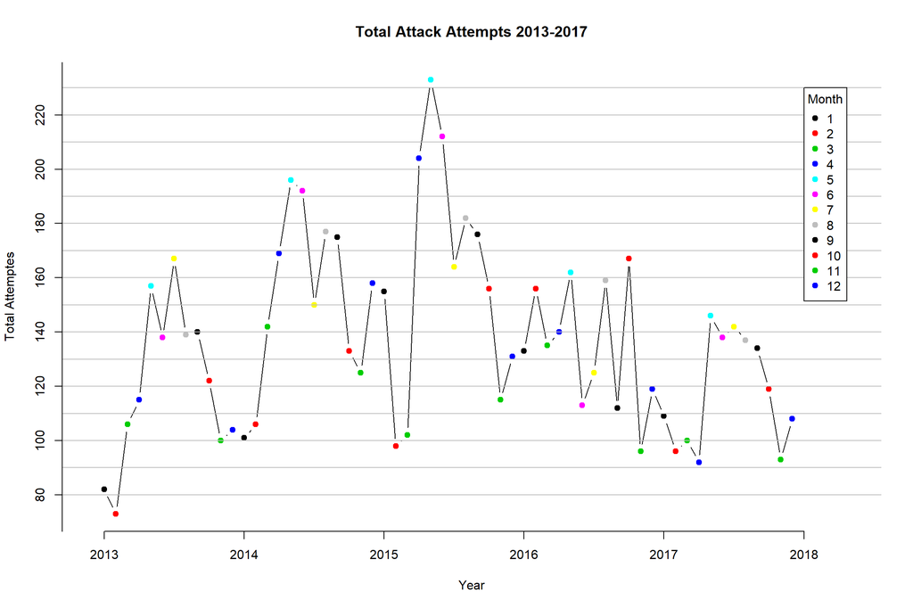

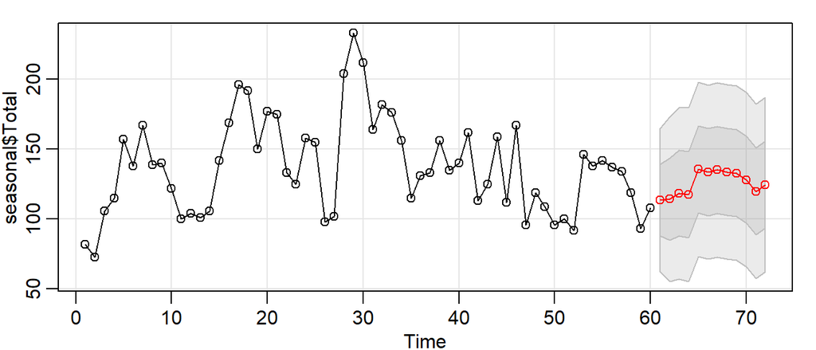

# Conclusion

Since the start of the war in Afghanistan, terrorist attack attempts have risen, closely mirroring successful attacks. After a troop surge in 2011, there was a drastic reduction in terrorist attacks, but after a steady troop redrawal, we have seen a drastic increase in terrorist attacks, most notably with the Taliban gaining more power over time.

It should be noted that since the start of this report, it has been announced that the United States will again be decreasing troop levels in Afghanistan. While these predictions may no longer be valid, it can be predicted that with this troop withdrawal, there will be increased terrorist attacks as was seen following the withdrawal in 2012. What this data can be useful in is carefully examining the variables in the data set more closely and fitting a logistic model to determine the odds of success for an attack. With decreased resources in Afghanistan, it will be more important than ever to find common factors in attacks to thwart potential threats in the future.